# Lab 5

Author

Melissa LaMette

# Packages

```python
import pandas as pd
from sklearn.pipeline import Pipeline
from sklearn.linear_model import LinearRegression
from sklearn.metrics import r2_score, mean_squared_error
from sklearn.preprocessing import OneHotEncoder, FunctionTransformer
from sklearn.model_selection import train_test_split
from sklearn.compose import ColumnTransformer
from sklearn.preprocessing import PolynomialFeatures
from plotnine import *
```

# Part One: Data Exploration

```python
insurance = pd.read_csv('https://www.dropbox.com/s/bocjjyo1ehr5auz/insurance_costs_1.csv?dl=1')
insurance
```

|  | age | sex | bmi | smoker | region | charges |
| --- | --- | --- | --- | --- | --- | --- |
| 0 | 19 | female | 27.900 | yes | southwest | 16884.92400 |
| 1 | 33 | male | 22.705 | no | northwest | 21984.47061 |
| 2 | 32 | male | 28.880 | no | northwest | 3866.85520 |
| 3 | 31 | female | 25.740 | no | southeast | 3756.62160 |
| 4 | 60 | female | 25.840 | no | northwest | 28923.13692 |
| ... | ... | ... | ... | ... | ... | ... |
| 426 | 23 | female | 33.400 | no | southwest | 10795.93733 |
| 427 | 18 | female | 31.920 | no | northeast | 2205.98080 |
| 428 | 18 | female | 36.850 | no | southeast | 1629.83350 |
| 429 | 21 | female | 25.800 | no | southwest | 2007.94500 |
| 430 | 61 | female | 29.070 | yes | northwest | 29141.36030 |

431 rows × 6 columns

```python
insurance.describe()
```

|  | age | bmi | charges |
| --- | --- | --- | --- |
| count | 431.000000 | 431.000000 | 431.000000 |
| mean | 37.960557 | 30.768898 | 12297.098118 |
| std | 16.363909 | 6.111362 | 11876.527128 |
| min | 18.000000 | 15.960000 | 1131.506600 |
| 25% | 22.000000 | 26.357500 | 2710.444575 |
| 50% | 34.000000 | 30.590000 | 9866.304850 |
| 75% | 55.000000 | 35.272500 | 14510.872600 |
| max | 64.000000 | 49.060000 | 55135.402090 |

```python
insurance[['age', 'sex']].head()
```

|  | age | sex |
| --- | --- | --- |
| 0 | 19 | female |
| 1 | 33 | male |
| 2 | 32 | male |
| 3 | 31 | female |
| 4 | 60 | female |

```python
# How many females have a bmi greater than thirty and are a smoker?
insurance[(insurance['bmi'] > 30) & (insurance['sex']=='female') & (insurance['smoker'] == 'yes')]
```

|  | age | sex | bmi | smoker | region | charges |
| --- | --- | --- | --- | --- | --- | --- |
| 28 | 57 | female | 31.16 | yes | northwest | 43578.93940 |
| 52 | 18 | female | 36.85 | yes | southeast | 36149.48350 |
| 56 | 63 | female | 37.70 | yes | southwest | 48824.45000 |
| 66 | 27 | female | 36.08 | yes | southeast | 37133.89820 |
| 98 | 27 | female | 31.40 | yes | southwest | 34838.87300 |
| 143 | 33 | female | 33.50 | yes | southwest | 37079.37200 |
| 163 | 44 | female | 38.06 | yes | southeast | 48885.13561 |
| 188 | 43 | female | 46.20 | yes | southeast | 45863.20500 |
| 210 | 19 | female | 33.11 | yes | southeast | 34439.85590 |
| 215 | 44 | female | 38.95 | yes | northwest | 42983.45850 |
| 238 | 51 | female | 38.06 | yes | southeast | 44400.40640 |
| 246 | 37 | female | 38.39 | yes | southeast | 40419.01910 |
| 266 | 18 | female | 42.24 | yes | southeast | 38792.68560 |
| 273 | 33 | female | 35.53 | yes | northwest | 55135.40209 |
| 284 | 60 | female | 32.45 | yes | southeast | 45008.95550 |
| 285 | 37 | female | 30.78 | yes | northeast | 37270.15120 |
| 286 | 46 | female | 35.53 | yes | northeast | 42111.66470 |
| 288 | 48 | female | 33.11 | yes | southeast | 40974.16490 |
| 358 | 22 | female | 30.40 | yes | northwest | 33907.54800 |
| 368 | 19 | female | 32.49 | yes | northwest | 36898.73308 |
| 419 | 25 | female | 30.20 | yes | southwest | 33900.65300 |

```python
# How many females are in this dataset?
insurance[insurance['sex'] == 'female']
```

|  | age | sex | bmi | smoker | region | charges |
| --- | --- | --- | --- | --- | --- | --- |
| 0 | 19 | female | 27.90 | yes | southwest | 16884.92400 |
| 3 | 31 | female | 25.74 | no | southeast | 3756.62160 |
| 4 | 60 | female | 25.84 | no | northwest | 28923.13692 |
| 6 | 62 | female | 26.29 | yes | southeast | 27808.72510 |
| 7 | 56 | female | 39.82 | no | southeast | 11090.71780 |
| ... | ... | ... | ... | ... | ... | ... |
| 426 | 23 | female | 33.40 | no | southwest | 10795.93733 |
| 427 | 18 | female | 31.92 | no | northeast | 2205.98080 |
| 428 | 18 | female | 36.85 | no | southeast | 1629.83350 |
| 429 | 21 | female | 25.80 | no | southwest | 2007.94500 |
| 430 | 61 | female | 29.07 | yes | northwest | 29141.36030 |

225 rows × 6 columns

```python
# How many females are smokers?
insurance[(insurance['sex'] == 'female') & (insurance['smoker']== 'yes')]
```

|  | age | sex | bmi | smoker | region | charges |
| --- | --- | --- | --- | --- | --- | --- |
| 0 | 19 | female | 27.900 | yes | southwest | 16884.92400 |
| 6 | 62 | female | 26.290 | yes | southeast | 27808.72510 |
| 20 | 20 | female | 22.420 | yes | northwest | 14711.74380 |
| 22 | 27 | female | 24.750 | yes | southeast | 16577.77950 |
| 28 | 57 | female | 31.160 | yes | northwest | 43578.93940 |
| 48 | 42 | female | 23.370 | yes | northeast | 19964.74630 |
| 52 | 18 | female | 36.850 | yes | southeast | 36149.48350 |
| 56 | 63 | female | 37.700 | yes | southwest | 48824.45000 |
| 66 | 27 | female | 36.080 | yes | southeast | 37133.89820 |
| 79 | 63 | female | 27.740 | yes | northeast | 29523.16560 |
| 98 | 27 | female | 31.400 | yes | southwest | 34838.87300 |
| 117 | 19 | female | 21.700 | yes | southwest | 13844.50600 |
| 121 | 23 | female | 28.310 | yes | northwest | 18033.96790 |
| 143 | 33 | female | 33.500 | yes | southwest | 37079.37200 |
| 163 | 44 | female | 38.060 | yes | southeast | 48885.13561 |
| 188 | 43 | female | 46.200 | yes | southeast | 45863.20500 |
| 204 | 19 | female | 28.310 | yes | northwest | 17468.98390 |
| 210 | 19 | female | 33.110 | yes | southeast | 34439.85590 |
| 215 | 44 | female | 38.950 | yes | northwest | 42983.45850 |
| 223 | 64 | female | 22.990 | yes | southeast | 27037.91410 |
| 238 | 51 | female | 38.060 | yes | southeast | 44400.40640 |
| 246 | 37 | female | 38.390 | yes | southeast | 40419.01910 |
| 250 | 37 | female | 26.400 | yes | southeast | 19539.24300 |
| 251 | 47 | female | 27.830 | yes | southeast | 23065.42070 |
| 256 | 19 | female | 28.880 | yes | northwest | 17748.50620 |
| 266 | 18 | female | 42.240 | yes | southeast | 38792.68560 |
| 273 | 33 | female | 35.530 | yes | northwest | 55135.40209 |
| 282 | 57 | female | 29.810 | yes | southeast | 27533.91290 |
| 284 | 60 | female | 32.450 | yes | southeast | 45008.95550 |
| 285 | 37 | female | 30.780 | yes | northeast | 37270.15120 |
| 286 | 46 | female | 35.530 | yes | northeast | 42111.66470 |
| 288 | 48 | female | 33.110 | yes | southeast | 40974.16490 |
| 297 | 64 | female | 26.885 | yes | northwest | 29330.98315 |
| 306 | 32 | female | 24.600 | yes | southwest | 17496.30600 |
| 329 | 24 | female | 20.520 | yes | northeast | 14571.89080 |
| 358 | 22 | female | 30.400 | yes | northwest | 33907.54800 |
| 368 | 19 | female | 32.490 | yes | northwest | 36898.73308 |
| 394 | 20 | female | 24.420 | yes | southeast | 26125.67477 |
| 418 | 29 | female | 21.850 | yes | northeast | 16115.30450 |
| 419 | 25 | female | 30.200 | yes | southwest | 33900.65300 |
| 430 | 61 | female | 29.070 | yes | northwest | 29141.36030 |

```python
insurance['charges'].mean()
```

```
12297.098118187932
```

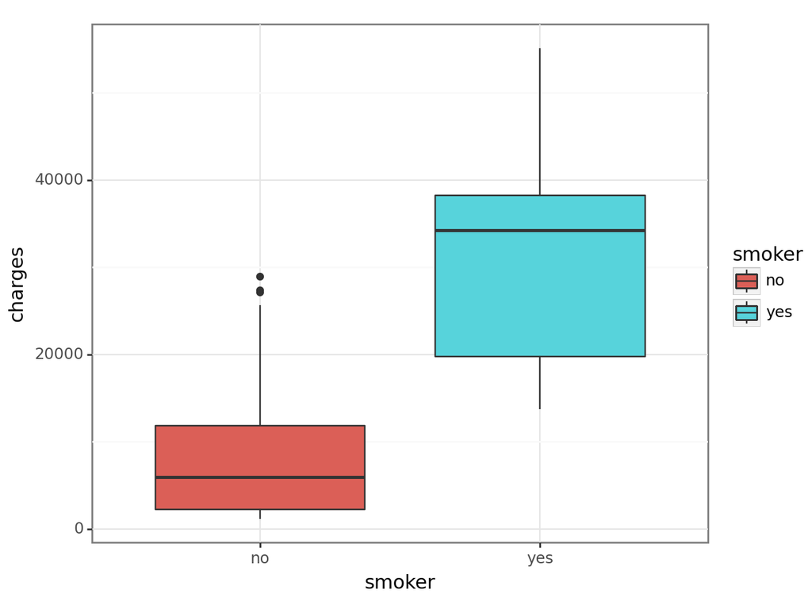

```
<Figure Size: (640 x 480)>
```

```python
# Plot 1 - The charges between nonsomkers and smokers

(ggplot(insurance, aes(x = 'smoker', y = 'charges', fill = 'smoker'))
+ geom_boxplot()
+ theme_bw())
```

Based on this plot, whether or not someone smokes plays a role in determining charges. There are many health effects that come from smoking that may require more medical treatment and intention and therefore more use of health insurance. This drives the insurance charges up.

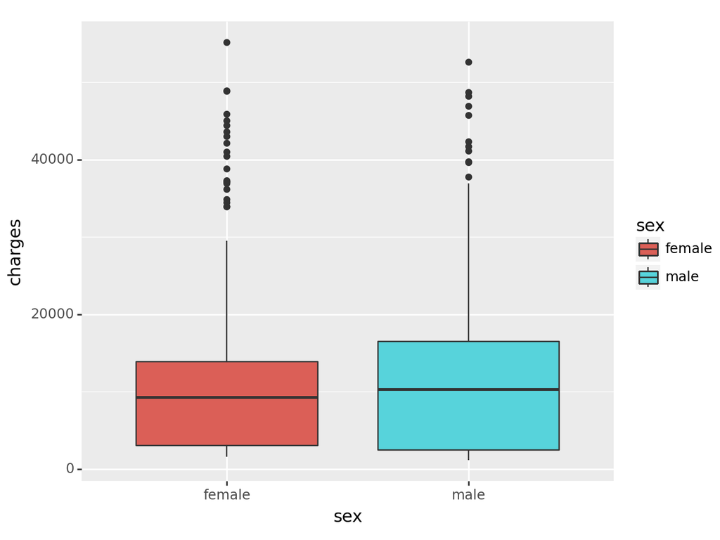

```
<Figure Size: (640 x 480)>
```

```python
# Plot 2 - Sex v. Charges
(ggplot(insurance, aes(x = 'sex', y = 'charges', fill = 'sex'))
+ geom_boxplot())
```

Based on this plot, it does not seem like charges vary based on sex. The mean charges for female and male are pretty close and the spread and variability of charges for each sex is pretty similar. Based on this plot, I would think sex is not a strong determinate in charges.

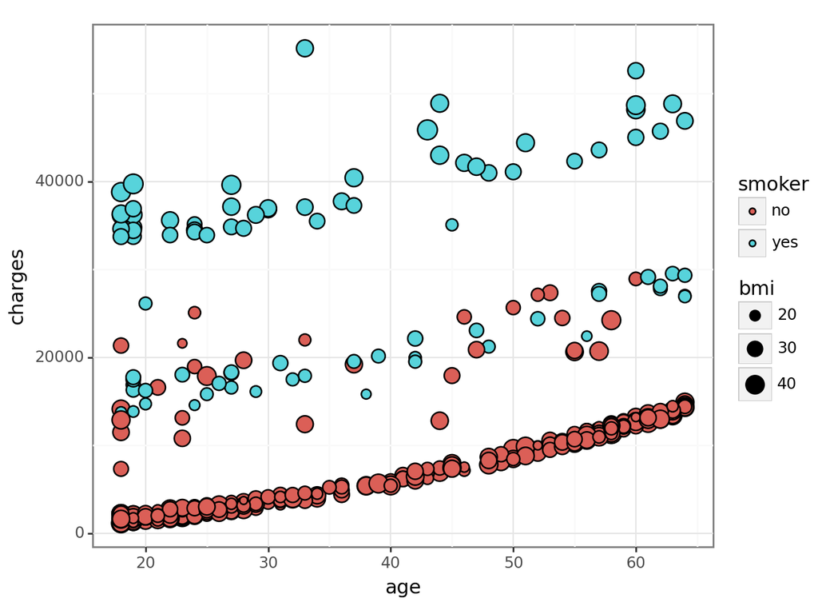

```
<Figure Size: (640 x 480)>
```

```python
# Plot 3- smoker,bmi,age
(ggplot(insurance, aes(x = 'age', y='charges', fill = 'smoker', size = 'bmi'))
+ geom_point()
+ theme_bw())
```

Majority of nonsmokers have charges below 20000 whereas smokers have charges around greater than 20000. As you can see by this plot, smokers tend to have higher charges than nonsmokers. One can also so that as age increases, charges increase. As a person gets older, they may experience more health issues due to old age and need more medical treatment which requires the use of their insurance.

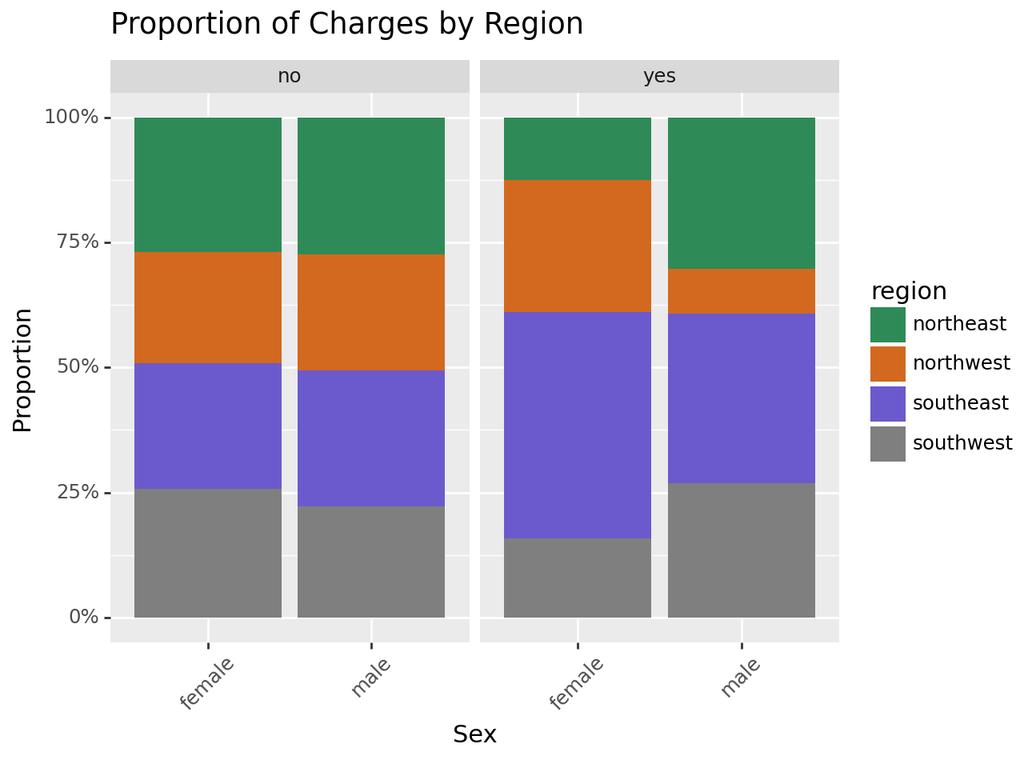

```
<Figure Size: (640 x 480)>
```

```python
# Plot 4: Proportion of Charges by Region
(ggplot(insurance,aes(x = 'sex', y = 'charges', fill = 'region'))
+ geom_col(position = 'fill')
+ labs(x = 'Sex', y = 'Proportion', title = 'Proportion of Charges by Region')
+ facet_wrap('smoker')
+ scale_y_continuous(labels=lambda l: ['{:.0%}'.format(v) for v in l]) #chatgpt
+ theme(axis_text_x = element_text(rotation = 45))
+ scale_fill_manual(values = ["seagreen", "chocolate", "slateblue"]))
```

This plot shows the distribution of charges between regions based on whether or not the primary beneficiary is a female or male and then smoker or nonsmoker. As we can see on the nonsmoker side, the distribution of charges between males and females and across all regions is relatively the same. However, when we look at the smoker side, for females, the southeast and northwest region make up a large part of the charges. For the males, the southeast and northeast regions make up the larger part of the charges.

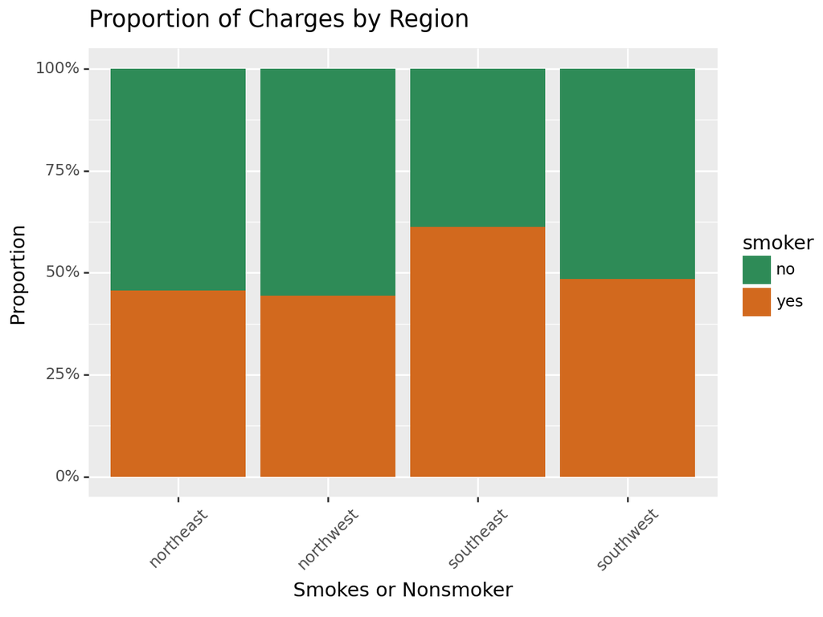

```
<Figure Size: (640 x 480)>
```

```python
# Plot 5: Proportion of Charges by sex
(ggplot(insurance,aes(x = 'region', y = 'charges', fill = 'smoker'))
+ geom_col(position = 'fill')
+ labs(x = 'Smokes or Nonsmoker', y = 'Proportion', title = 'Proportion of Charges by Region')
+ scale_y_continuous(labels=lambda l: ['{:.0%}'.format(v) for v in l]) #chatgpt
+ theme(axis_text_x = element_text(rotation = 45))
+ scale_fill_manual(values = ["seagreen", "chocolate", "slateblue"]))
```

As we can see the proportion of charges is larger for smokers in the southeast region. However, the proportion of charges is larger for nonsmokers in the northeast, northwest, and southwest region.

# Part Two: Simple Linear Models

```python
# Model 1: Simple Linear model to predict insurance charges from beneficiary's age

# X is a DataFrame
X = insurance[['age']] # still a two-dimensional object # double brackets to make it a dataframe

# y is a series
y = insurance['charges'] # list of one thing

X_train, X_test, y_train, y_test = train_test_split(X,y)
```

```python
lr = LinearRegression() # import linear regression function



my_pipeline = Pipeline([('ols',lr)] # just labeling it as linear regression; ols stands for...idk
)
# Fitted quadratic Model
fitted_pipeline = my_pipeline.fit(X_train, y_train)
fitted_pipeline

# Predict y values on Quadratic model (test)
y_predicted = fitted_pipeline.predict(X_test)
y_predicted
```

```
array([17499.74529549, 15420.48462372, 12417.10809782,  8258.58675427,
        8489.6157178 , 18192.83218609, 12417.10809782, 17730.77425902,
        8258.58675427,  9644.76053545, 11492.9922437 ,  8489.6157178 ,
       11955.05017076, 12417.10809782, 17730.77425902, 15882.54255078,
       10337.84742605, 16344.60047784,  9875.78949898,  8489.6157178 ,
       13110.19498841,  9413.73157192, 11030.93431664, 14496.3687696 ,
        8489.6157178 ,  8258.58675427, 17037.68736843, 18654.89011315,
       16806.6584049 , 11724.02120723,  9413.73157192, 18654.89011315,
       15651.51358725,  8258.58675427,  9182.70260839, 12879.16602488,
        8489.6157178 ,  9182.70260839,  8258.58675427, 11261.96328017,
        9875.78949898,  8951.67364486, 13803.281879  , 18885.91907668,
       13572.25291547, 11492.9922437 , 11261.96328017, 15882.54255078,
        9644.76053545, 10568.87638958, 11955.05017076,  8258.58675427,
        8258.58675427, 15189.45566019,  8258.58675427,  8720.64468133,
        9413.73157192, 14496.3687696 , 15651.51358725, 16113.57151431,
        8489.6157178 ,  8489.6157178 , 16806.6584049 ,  9875.78949898,
       11261.96328017,  9182.70260839,  8258.58675427,  9413.73157192,
       17730.77425902, 15882.54255078, 17268.71633196,  8258.58675427,
       17268.71633196,  8720.64468133, 17961.80322256, 10799.90535311,
       17961.80322256, 17037.68736843, 18192.83218609,  8258.58675427,
        8720.64468133, 17961.80322256, 18885.91907668, 16806.6584049 ,
       18885.91907668, 17499.74529549, 10337.84742605,  8489.6157178 ,
       10106.81846252,  8258.58675427, 16806.6584049 ,  8951.67364486,
        9875.78949898, 11955.05017076,  9644.76053545, 10106.81846252,
        9413.73157192, 10799.90535311, 14727.39773313, 18192.83218609,
        8258.58675427, 17961.80322256, 13803.281879  ,  8489.6157178 ,
       16806.6584049 ,  9182.70260839, 18654.89011315, 11030.93431664])
```

```python
# Coefficients
fitted_pipeline.named_steps['ols'].coef_
```

```
array([231.02896353])
```

```python
r2_score(y_test, y_predicted)
```

```
0.06229062252642503
```

This r2 is really low and is not a good fit based on this metric.

```python
# Combine Arrays and make into a dataframe
#dataset = pd.DataFrame({'label': label, 'images': list(images)}, columns=['label', 'images'])
model1 = pd.DataFrame({'y predicted':y_predicted,'actual':y_test,'age':X_test['age']}, columns=['y predicted','actual','age'])
model1
```

|  | y predicted | actual | age |
| --- | --- | --- | --- |
| 95 | 17499.745295 | 11944.59435 | 58 |
| 304 | 15420.484624 | 8125.78450 | 49 |
| 226 | 12417.108098 | 4399.73100 | 36 |
| 376 | 8258.586754 | 2200.83085 | 18 |
| 319 | 8489.615718 | 1628.47090 | 19 |
| ... | ... | ... | ... |
| 154 | 8489.615718 | 1744.46500 | 19 |
| 357 | 16806.658405 | 11286.53870 | 55 |
| 12 | 9182.702608 | 35585.57600 | 22 |
| 53 | 18654.890113 | 13405.39030 | 63 |
| 36 | 11030.934317 | 3645.08940 | 30 |

108 rows × 3 columns

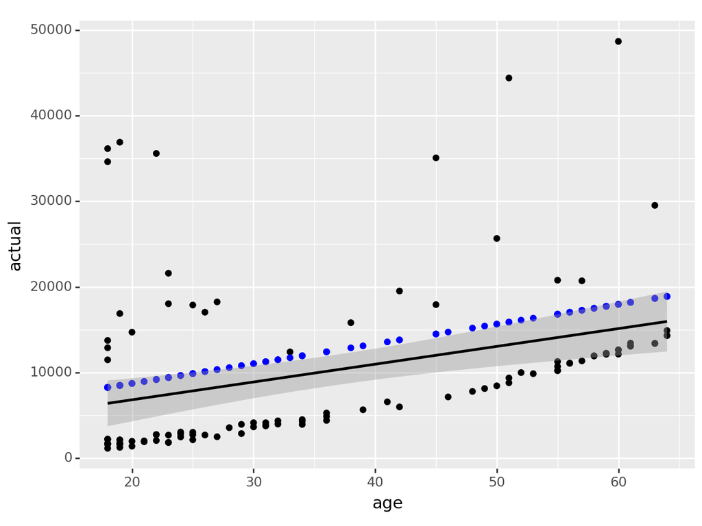

```
<Figure Size: (640 x 480)>
```

```python
# Plot Simple Lienar Regression
(ggplot(model1, aes(x = 'age', y = 'actual'))
+ geom_point(aes(y='actual'), color = 'black')
+ geom_point(aes(y = 'y predicted'), color = 'blue')
+ geom_smooth(method='lm'))
```

```python
# Model 2: Simple Linear Regression Model predict insurance charges from beneficiary's age

# X is a DataFrame
X = insurance[['sex','age']] # still a two-dimensional object # double brackets to make it a dataframe

# y is a series
y = insurance['charges'] # list of one thing

X_train2, X_test2, y_train2, y_test2 = train_test_split(X,y)
```

```python
# Dummify necessary variables

lr = LinearRegression()
enc = OneHotEncoder() # helps automatically dummify variables

ct2 = ColumnTransformer([ ('dummify_sex', enc, ['sex'])]
)

my_pipeline2 = Pipeline(
    [('dummify_everything',ct2),
    ('ols',lr)] # just labeling it as linear regression; ols stands for...idk
)
```

```python
fitted_pipeline2 = my_pipeline2.fit(X_train2, y_train2)
fitted_pipeline2
y_predicted2 = fitted_pipeline2.predict(X_test2)
y_predicted2
```

```
array([11712., 13184., 11712., 13184., 11712., 11712., 13184., 11712.,
       13184., 13184., 11712., 13184., 11712., 11712., 11712., 11712.,
       11712., 13184., 13184., 11712., 11712., 13184., 11712., 13184.,
       13184., 13184., 11712., 11712., 11712., 11712., 11712., 11712.,
       13184., 13184., 13184., 11712., 11712., 13184., 11712., 13184.,
       11712., 11712., 13184., 13184., 13184., 11712., 11712., 11712.,
       11712., 13184., 13184., 13184., 13184., 11712., 11712., 13184.,
       13184., 11712., 13184., 13184., 13184., 11712., 11712., 11712.,
       13184., 13184., 13184., 11712., 13184., 11712., 11712., 13184.,
       13184., 11712., 13184., 13184., 13184., 13184., 11712., 11712.,
       13184., 13184., 13184., 13184., 11712., 11712., 11712., 11712.,
       13184., 13184., 13184., 13184., 11712., 13184., 11712., 11712.,
       11712., 11712., 11712., 13184., 13184., 13184., 11712., 13184.,
       11712., 11712., 13184., 13184.])
```

```python
# Coefficients - How do you interpret these results?
fitted_pipeline2.named_steps['ols'].coef_
```

```
array([-4.50644604e+17, -4.50644604e+17])
```

```python
# Model 3: Simple Linear Regression Model includes smoker but NOT sex

# X is a DataFrame
X = insurance[['age','smoker']] # still a two-dimensional object # double brackets to make it a dataframe

# y is a series
y = insurance['charges'] # list of one thing

X_train3, X_test3, y_train3, y_test3 = train_test_split(X,y)
```

```python
lr = LinearRegression()
enc = OneHotEncoder() # helps automatically dummify variables

ct3 = ColumnTransformer([ ('dummify_smoke', enc, ['smoker'])]
)

my_pipeline3 = Pipeline(
    [('dummify_everything',ct3),
    ('ols',lr)] # just labeling it as linear regression; ols stands for...idk
)
```

```python
fitted_pipeline3 = my_pipeline3.fit(X_train3, y_train3)
fitted_pipeline3
y_predicted3 = fitted_pipeline3.predict(X_test3)
y_predicted3
```

```
array([ 8192.,  8192.,  8192.,  8192.,  8192.,  8192.,  8192.,  8192.,
        8192.,  8192.,  8192.,  8192.,  8192.,  8192.,  8192.,  8192.,
       28672.,  8192.,  8192.,  8192.,  8192., 28672.,  8192.,  8192.,
        8192.,  8192.,  8192.,  8192., 28672.,  8192., 28672.,  8192.,
        8192., 28672.,  8192., 28672., 28672., 28672., 28672., 28672.,
        8192.,  8192.,  8192.,  8192.,  8192., 28672., 28672.,  8192.,
       28672., 28672.,  8192.,  8192., 28672.,  8192.,  8192.,  8192.,
        8192.,  8192.,  8192.,  8192.,  8192.,  8192.,  8192.,  8192.,
        8192.,  8192., 28672.,  8192.,  8192.,  8192., 28672.,  8192.,
        8192.,  8192.,  8192.,  8192.,  8192.,  8192.,  8192.,  8192.,
        8192.,  8192., 28672.,  8192., 28672.,  8192., 28672., 28672.,
        8192.,  8192.,  8192., 28672., 28672.,  8192.,  8192.,  8192.,
        8192.,  8192.,  8192.,  8192.,  8192., 28672., 28672.,  8192.,
       28672.,  8192., 28672.,  8192.])
```

```python
# Coefficients - How do you interpret these results? Why are they the same?
fitted_pipeline2.named_steps['ols'].coef_
```

```
array([-4.50644604e+17, -4.50644604e+17])
```

```python
# MSE Calculations

mse = mean_squared_error(y_test2, y_predicted2)
mse

mse2 = mean_squared_error(y_test3, y_predicted3)
mse2
```

```
69468347.98456782
```

mse = 120016874.20027162

```python
# r2 Calculations
m1 = r2_score(y_test2, y_predicted2)
m1
m2 = r2_score(y_test3, y_predicted3)
m2
```

```
0.602249200351796
```

CONCLUSION:

model 3 from question 3 is better.

# Part Three: Multiple Linear Models

```python
# Model 1 - age and bmi

X = insurance.drop('charges', axis = 1)
y = insurance['charges']

X_train, X_test, y_train, y_test = train_test_split(X,y)
```

```python
ct = ColumnTransformer(
  [  (("keep", FunctionTransformer(lambda x: x), ["bmi", "age"]))
  ],
  remainder = "drop"
)


lr_pipeline = Pipeline(
  [("preprocessing", ct),
  ("linear_regression", LinearRegression())]
)

lr_pipeline
```

```
Pipeline(steps=[('preprocessing',
                 ColumnTransformer(transformers=[('keep',
                                                  FunctionTransformer(func=<function <lambda> at 0x78b54f9cf490>),
                                                  ['bmi', 'age'])])),
                ('linear_regression', LinearRegression())])
```

```python
lr_fitted = lr_pipeline.fit(X_train, y_train) # calculating the coefficients
lr_fitted

# Get coefficients
lr_fitted.named_steps['linear_regression'].coef_

# Make predictions of House Prices with coefficients

y_preds = lr_fitted.predict(X_test)
y_preds
r2_score(y_test, y_preds)
#mean_squared_error(y_test, y_preds)
```

```
0.02607939909578305
```

mse: 136880758.69846004

```python
# Model 2: Age and age^2

ct = ColumnTransformer(
  [  (("keep", FunctionTransformer(lambda x: x), ["age"]))
  ],
  remainder = "drop"
)

poly = PolynomialFeatures(2)

# recipe, machine that generates linear regression, throw in your parts, variables
my_pipeline = Pipeline(
    [("preprocessing", ct), ('quadratic', poly), ('ols', lr) ])

# Fitted quadratic Model
fitted_pipeline_q = my_pipeline.fit(X_train, y_train)
fitted_pipeline_q

# Predict y values on Quadratic model
y_predicted_q = fitted_pipeline_q.predict(X_test)
y_predicted_q
```

```python
# Calculations for r2 and mse
r2_score(y_test, y_predicted_q)
#mean_squared_error(y_test, y_predicted_q)
```

```
-0.020883874337570996
```

```python
# Model 3: Polynomial degree 4
ct = ColumnTransformer(
  [  (("keep", FunctionTransformer(lambda x: x), ["age"]))
  ],
  remainder = "drop"
)

poly = PolynomialFeatures(4)

# recipe, machine that generates linear regression, throw in your parts, variables
my_pipeline = Pipeline(
    [("preprocessing", ct), ('quadratic', poly), ('ols', lr) ])

# Fitted quadratic Model
fitted_pipeline_q = my_pipeline.fit(X_train, y_train)
fitted_pipeline_q

# Predict y values on Quadratic model
y_predicted_q = fitted_pipeline_q.predict(X_test)
y_predicted_q
```

```python
# Calculations for r2 and mse
r2_score(y_test, y_predicted_q)
#mean_squared_error(y_test, y_predicted_q)
```

```
0.12557387312773938
```

r2: 0.12557387312773938

mse: 142232590.49439913

This model did better than the one from Part 2 Question 1.

```python
# Model 4: Polynomial degree 12
ct = ColumnTransformer(
  [  (("keep", FunctionTransformer(lambda x: x), ["age"]))
  ],
  remainder = "drop"
)

poly = PolynomialFeatures(12)

# recipe, machine that generates linear regression, throw in your parts, variables
my_pipeline = Pipeline(
    [("preprocessing", ct), ('quadratic', poly), ('ols', lr) ])

# Fitted quadratic Model
fitted_pipeline_q = my_pipeline.fit(X_train, y_train)
fitted_pipeline_q

# Predict y values on Quadratic model
y_predicted_q = fitted_pipeline_q.predict(X_test)
y_predicted_q
```

```python
# Calculations for r2 and mse
r2_score(y_test, y_predicted_q)
#mean_squared_error(y_test, y_predicted_q)
```

```
0.10902502741285924
```

mse: 150793529.21919194

This model did better than the one in Part 2 Question 1.

## Conclusion

### Plot

```python
# DataFrame
plot = pd.DataFrame({'poly_12':y_predicted_q,"y":y_test,'age':X_test['age']}, columns=['poly_12','y','age'])
plot
```

|  | poly_12 | y | age |
| --- | --- | --- | --- |
| 213 | 15560.786700 | 12129.61415 | 59 |
| 405 | 13226.444693 | 10704.47000 | 55 |
| 308 | 8956.739093 | 2473.33410 | 24 |
| 388 | 12367.685233 | 4134.08245 | 31 |
| 45 | 8137.069305 | 2045.68525 | 22 |
| ... | ... | ... | ... |
| 333 | 13898.070371 | 8269.04400 | 48 |
| 300 | 18029.688177 | 13063.88300 | 61 |
| 200 | 7266.564139 | 1242.81600 | 19 |
| 228 | 14077.029857 | 7222.78625 | 45 |
| 15 | 16779.799140 | 48173.36100 | 60 |

108 rows × 3 columns

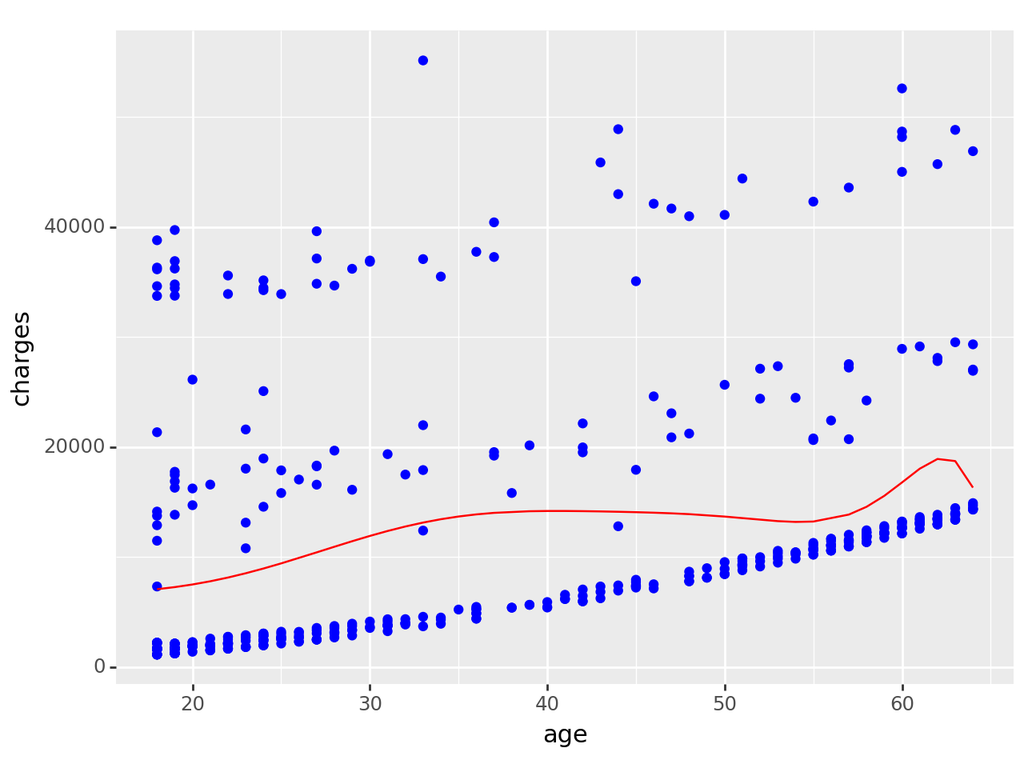

```
<Figure Size: (640 x 480)>
```

```python
# plot
(ggplot(insurance, aes(x = 'age', y = 'charges'))
+ geom_point(aes( y = 'charges'), color = 'blue')
+ geom_line(plot, aes(y = 'poly_12'), color = 'red'))
```

# Part Four: New data

```python
insurance2 = pd.read_csv('https://www.dropbox.com/s/sky86agc4s8c6qe/insurance_costs_2.csv?dl=1')
insurance2
```

|  | age | sex | bmi | smoker | region | charges |
| --- | --- | --- | --- | --- | --- | --- |
| 0 | 23 | male | 34.400 | no | southwest | 1826.84300 |
| 1 | 56 | male | 40.300 | no | southwest | 10602.38500 |
| 2 | 18 | male | 34.100 | no | southeast | 1137.01100 |
| 3 | 63 | female | 23.085 | no | northeast | 14451.83515 |
| 4 | 63 | male | 28.310 | no | northwest | 13770.09790 |
| ... | ... | ... | ... | ... | ... | ... |
| 138 | 19 | male | 34.900 | yes | southwest | 34828.65400 |
| 139 | 45 | male | 30.360 | yes | southeast | 62592.87309 |
| 140 | 43 | male | 27.800 | yes | southwest | 37829.72420 |
| 141 | 24 | female | 27.720 | no | southeast | 2464.61880 |
| 142 | 18 | male | 53.130 | no | southeast | 1163.46270 |

143 rows × 6 columns

```python
# Split new data
X2 = insurance2.drop('charges', axis = 1) # still a two-dimensional object

# y is a series
y2 = insurance2['charges'] # list of one thing

X_train2, X_test2, y_train2, y_test2 = train_test_split(X2,y2)
```

## Model 1 - age

```python
# Model 1 - age
ct = ColumnTransformer(
  [  (("keep", FunctionTransformer(lambda x: x), ["age"]))
  ],
  remainder = "drop"
)


lr_pipeline = Pipeline(
  [("preprocessing", ct),
  ("linear_regression", LinearRegression())]
)

lr_pipeline
```

```
Pipeline(steps=[('preprocessing',
                 ColumnTransformer(transformers=[('keep',
                                                  FunctionTransformer(func=<function <lambda> at 0x78b5501e6e60>),
                                                  ['age'])])),
                ('linear_regression', LinearRegression())])
```

```python
# fit on old
lr_fitted = lr_pipeline.fit(X_train, y_train) # calculating the coefficients
lr_fitted

# predict on new data
y_predicted = lr_fitted.predict(X_test2)
y_predicted

# mse calculations
mean_squared_error(y_test2, y_predicted)
```

```
167840085.03602827
```

## Model 2 - age and bmi

```python
# Model 2 - age and bmi
ct = ColumnTransformer(
  [  (("keep", FunctionTransformer(lambda x: x), ["bmi", "age"]))
  ],
  remainder = "drop"
)


lr_pipeline = Pipeline(
  [("preprocessing", ct),
  ("linear_regression", LinearRegression())]
)

lr_pipeline
```

```
Pipeline(steps=[('preprocessing',
                 ColumnTransformer(transformers=[('keep',
                                                  FunctionTransformer(func=<function <lambda> at 0x78b5501e7490>),
                                                  ['bmi', 'age'])])),
                ('linear_regression', LinearRegression())])
```

```python
# fit on old
lr_fitted = lr_pipeline.fit(X_train, y_train) # calculating the coefficients
lr_fitted

# predict on new data
y_predicted = lr_fitted.predict(X_test2)
y_predicted

# mse calculations
mean_squared_error(y_test2, y_predicted)
```

```
161748139.0746392
```

## Model 3 - age, bmi, smoker

```python
# Model 3 - age, bmi, smoker

ct = ColumnTransformer(
  [ ("dummify", OneHotEncoder(sparse_output = False),["smoker"]),
   (("keep", FunctionTransformer(lambda x: x), ["bmi","age"]))
  ],
  remainder = "drop"
)


lr_pipeline = Pipeline(
  [("preprocessing", ct),
  ("linear_regression", LinearRegression())]
)

lr_pipeline
```

```
Pipeline(steps=[('preprocessing',
                 ColumnTransformer(transformers=[('dummify',
                                                  OneHotEncoder(sparse_output=False),
                                                  ['smoker']),
                                                 ('keep',
                                                  FunctionTransformer(func=<function <lambda> at 0x78b5501e7c70>),
                                                  ['bmi', 'age'])])),
                ('linear_regression', LinearRegression())])
```

```python
# fit on old
lr_fitted = lr_pipeline.fit(X_train, y_train) # calculating the coefficients
lr_fitted

# predict on new data
y_predicted = lr_fitted.predict(X_test2)
y_predicted

# mse calculations
mean_squared_error(y_test2, y_predicted)
```

```
31393295.17092108
```

## Model 4 - age, bmi, interaction between age & smoker, bmi & smoker

```python
# Dummify dummy variables
insurance = pd.get_dummies(insurance, columns = ['smoker'])
insurance2 = pd.get_dummies(insurance2, columns = ['smoker'])
insurance
insurance2
```

|  | age | sex | bmi | region | charges | smoker_no | smoker_yes |
| --- | --- | --- | --- | --- | --- | --- | --- |
| 0 | 23 | male | 34.400 | southwest | 1826.84300 | 1 | 0 |
| 1 | 56 | male | 40.300 | southwest | 10602.38500 | 1 | 0 |
| 2 | 18 | male | 34.100 | southeast | 1137.01100 | 1 | 0 |
| 3 | 63 | female | 23.085 | northeast | 14451.83515 | 1 | 0 |
| 4 | 63 | male | 28.310 | northwest | 13770.09790 | 1 | 0 |
| ... | ... | ... | ... | ... | ... | ... | ... |
| 138 | 19 | male | 34.900 | southwest | 34828.65400 | 0 | 1 |
| 139 | 45 | male | 30.360 | southeast | 62592.87309 | 0 | 1 |
| 140 | 43 | male | 27.800 | southwest | 37829.72420 | 0 | 1 |
| 141 | 24 | female | 27.720 | southeast | 2464.61880 | 1 | 0 |
| 142 | 18 | male | 53.130 | southeast | 1163.46270 | 1 | 0 |

143 rows × 7 columns

```python
# Make iteraction variable columns
insurance['interaction_smoker_age_yes'] = insurance['smoker_no'] * insurance['age']
insurance['interaction_smoker_age_no'] = insurance['smoker_yes'] * insurance['age']
insurance['interaction_smoker_bmi_yes'] = insurance['smoker_no'] * insurance['bmi']
insurance['interaction_smoker_bmi_no'] = insurance['smoker_yes'] * insurance['bmi']
insurance

insurance2['interaction_smoker_age_yes'] = insurance2['smoker_no'] * insurance2['age']
insurance2['interaction_smoker_age_no'] = insurance2['smoker_yes'] * insurance2['age']
insurance2['interaction_smoker_bmi_yes'] = insurance2['smoker_no'] * insurance2['bmi']
insurance2['interaction_smoker_bmi_no'] = insurance2['smoker_yes'] * insurance2['bmi']
insurance2
```

|  | age | sex | bmi | region | charges | smoker_no | smoker_yes | interaction_smoker_age_yes | interaction_smoker_age_no | interaction_smoker_bmi_yes | interaction_smoker_bmi_no |
| --- | --- | --- | --- | --- | --- | --- | --- | --- | --- | --- | --- |
| 0 | 23 | male | 34.400 | southwest | 1826.84300 | 1 | 0 | 23 | 0 | 34.400 | 0.00 |
| 1 | 56 | male | 40.300 | southwest | 10602.38500 | 1 | 0 | 56 | 0 | 40.300 | 0.00 |
| 2 | 18 | male | 34.100 | southeast | 1137.01100 | 1 | 0 | 18 | 0 | 34.100 | 0.00 |
| 3 | 63 | female | 23.085 | northeast | 14451.83515 | 1 | 0 | 63 | 0 | 23.085 | 0.00 |
| 4 | 63 | male | 28.310 | northwest | 13770.09790 | 1 | 0 | 63 | 0 | 28.310 | 0.00 |
| ... | ... | ... | ... | ... | ... | ... | ... | ... | ... | ... | ... |
| 138 | 19 | male | 34.900 | southwest | 34828.65400 | 0 | 1 | 0 | 19 | 0.000 | 34.90 |
| 139 | 45 | male | 30.360 | southeast | 62592.87309 | 0 | 1 | 0 | 45 | 0.000 | 30.36 |
| 140 | 43 | male | 27.800 | southwest | 37829.72420 | 0 | 1 | 0 | 43 | 0.000 | 27.80 |
| 141 | 24 | female | 27.720 | southeast | 2464.61880 | 1 | 0 | 24 | 0 | 27.720 | 0.00 |
| 142 | 18 | male | 53.130 | southeast | 1163.46270 | 1 | 0 | 18 | 0 | 53.130 | 0.00 |

143 rows × 11 columns

```python
# Define X and Y again

# Old insurance data
X = insurance.drop('charges', axis = 1)
y = insurance['charges'] # list of one thing

X_train, X_test, y_train, y_test = train_test_split(X,y)

# New insurance data
X2 = insurance2.drop('charges', axis = 1) # still a two-dimensional object

# y is a series
y2 = insurance2['charges'] # list of one thing

X_train2, X_test2, y_train2, y_test2 = train_test_split(X2,y2)
```

```python
# Model 4: age, bmi, interaction between age & smoker, bmi & smoker
ct = ColumnTransformer(
  [
   (("keep", FunctionTransformer(lambda x: x), ["bmi","age",
                                                "interaction_smoker_age_yes",
                                                "interaction_smoker_age_no",
                                                "interaction_smoker_bmi_yes",
                                                "interaction_smoker_bmi_no"]))
  ],
  remainder = "drop"
)


lr_pipeline = Pipeline(
  [("preprocessing", ct),
  ("linear_regression", LinearRegression())]
)

lr_pipeline
```

```
Pipeline(steps=[('preprocessing',
                 ColumnTransformer(transformers=[('keep',
                                                  FunctionTransformer(func=<function <lambda> at 0x78b5502245e0>),
                                                  ['bmi', 'age',
                                                   'interaction_smoker_age_yes',
                                                   'interaction_smoker_age_no',
                                                   'interaction_smoker_bmi_yes',
                                                   'interaction_smoker_bmi_no'])])),
                ('linear_regression', LinearRegression())])
```

```python
# fit on old
lr_fitted = lr_pipeline.fit(X_train, y_train) # calculating the coefficients
lr_fitted

# predict on new data
y_predicted = lr_fitted.predict(X_test2)
y_predicted

# mse calculations
mean_squared_error(y_test2, y_predicted)
```

```
16150415.748673039
```

## Model 5: age, bmi, smoker, smoker & age, smoker & bmi

```python
# Model 5: age, bmi, smoker, smoker & age, smoker & bmi

ct = ColumnTransformer(
  [
   (("keep", FunctionTransformer(lambda x: x), ["bmi","age","smoker_no",
                                                "smoker_yes",
                                                "interaction_smoker_age_yes",
                                                "interaction_smoker_age_no",
                                                "interaction_smoker_bmi_yes",
                                                "interaction_smoker_bmi_no"]))
  ],
  remainder = "drop"
)


lr_pipeline = Pipeline(
  [("preprocessing", ct),
  ("linear_regression", LinearRegression())]
)

lr_pipeline
```

```
Pipeline(steps=[('preprocessing',
                 ColumnTransformer(transformers=[('keep',
                                                  FunctionTransformer(func=<function <lambda> at 0x78b5502256c0>),
                                                  ['bmi', 'age', 'smoker_no',
                                                   'smoker_yes',
                                                   'interaction_smoker_age_yes',
                                                   'interaction_smoker_age_no',
                                                   'interaction_smoker_bmi_yes',
                                                   'interaction_smoker_bmi_no'])])),
                ('linear_regression', LinearRegression())])
```

```python
# fit on old
lr_fitted = lr_pipeline.fit(X_train, y_train) # calculating the coefficients
lr_fitted

# predict on new data
y_predicted = lr_fitted.predict(X_test2)
y_predicted

# mse calculations
mean_squared_error(y_test2, y_predicted)
r2_score(y_test2, y_predicted)
```

```
0.9446945704043324
```

mse: 31965943.019181386

### Plot - Residuals of Model 5

```python
plot = pd.DataFrame({'prediction':y_predicted,"actual y":y_test2}, columns=['prediction','actual y'])
plot

plot['residuals'] = plot['actual y'] - plot['prediction']
plot
```

|  | prediction | actual y | residuals |
| --- | --- | --- | --- |
| 104 | 3726.903724 | 1972.95000 | -1753.953724 |
| 26 | 2098.956966 | 1631.82120 | -467.135766 |
| 106 | 7493.434498 | 5383.53600 | -2109.898498 |
| 130 | 2104.081731 | 1135.94070 | -968.141031 |
| 22 | 26273.526305 | 21348.70600 | -4924.820305 |
| 116 | 12603.604834 | 11353.22760 | -1250.377234 |
| 75 | 10724.718791 | 8827.20990 | -1897.508891 |
| 107 | 2910.279962 | 2020.17700 | -890.102962 |
| 51 | 12604.686728 | 11840.77505 | -763.911678 |
| 2 | 2103.284545 | 1137.01100 | -966.273545 |
| 132 | 26921.791444 | 18648.42170 | -8273.369744 |
| 8 | 8022.883266 | 5920.10410 | -2102.779166 |
| 81 | 11529.674655 | 9869.81020 | -1659.864455 |
| 10 | 43508.805816 | 47055.53210 | 3546.726284 |
| 44 | 2371.368497 | 2134.90150 | -236.466997 |
| 58 | 59544.695709 | 63770.42801 | 4225.732301 |
| 56 | 13949.263241 | 14043.47670 | 94.213459 |
| 68 | 3723.280153 | 1977.81500 | -1745.465153 |
| 76 | 2385.236421 | 1627.28245 | -757.953971 |
| 32 | 14224.138801 | 14256.19280 | 32.053999 |
| 49 | 2646.145702 | 1769.53165 | -876.614052 |
| 111 | 27267.251789 | 33475.81715 | 6208.565361 |
| 11 | 7220.950496 | 4646.75900 | -2574.191496 |
| 112 | 34176.142434 | 39727.61400 | 5551.471566 |
| 87 | 2913.903533 | 1526.31200 | -1387.591533 |
| 64 | 8287.840594 | 5709.16440 | -2578.676194 |
| 97 | 26919.177937 | 21774.32215 | -5144.855787 |
| 108 | 41851.402197 | 44423.80300 | 2572.400803 |
| 41 | 12612.259992 | 11830.60720 | -781.652792 |
| 91 | 6963.110897 | 5458.04645 | -1505.064447 |
| 37 | 11252.407538 | 9144.56500 | -2107.842538 |
| 46 | 44184.224160 | 46599.10840 | 2414.884240 |
| 126 | 26063.873134 | 33307.55080 | 7243.677666 |
| 18 | 13690.124334 | 13616.35860 | -73.765734 |
| 31 | 39774.465334 | 43921.18370 | 4146.718366 |
| 73 | 2371.109670 | 1263.24900 | -1107.860670 |

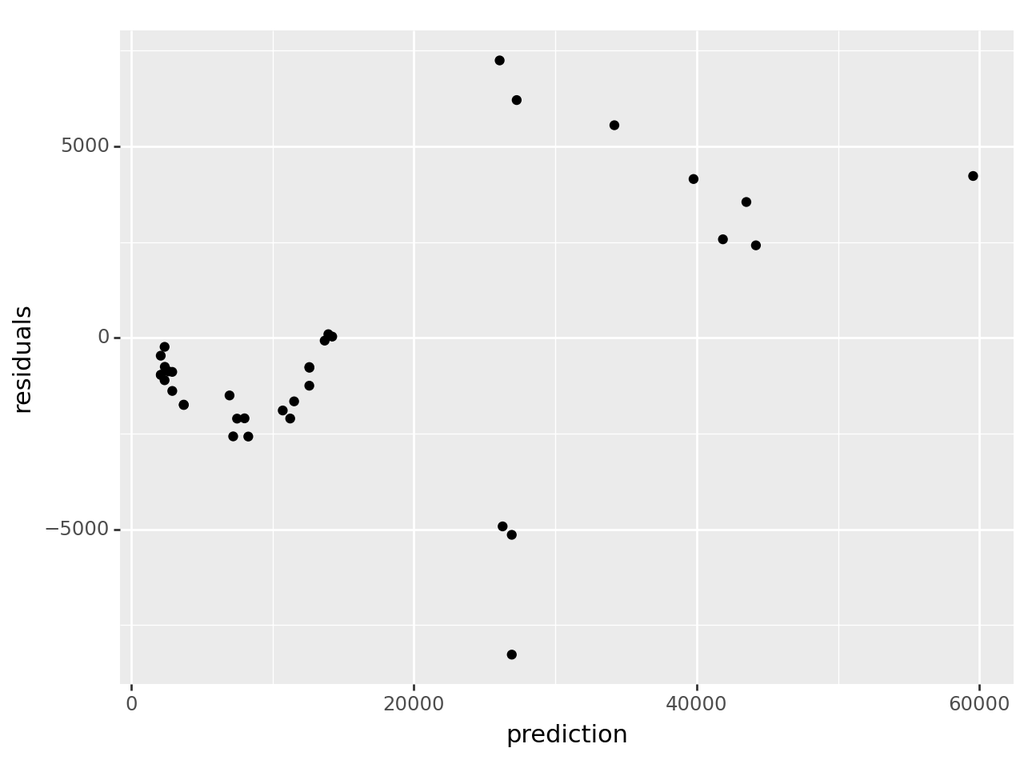

```
<Figure Size: (640 x 480)>
```

```python
# plot
(ggplot(plot, aes(x = 'prediction', y = 'residuals'))
+ geom_point( color = 'black'))
```

# Part Five: Full Exploration

```python
insurance['interaction_smoker_age_bmi_yes'] = insurance['smoker_no'] * insurance['bmi'] * insurance['age']
insurance['interaction_smoker_age_bmi_no'] = insurance['smoker_yes'] * insurance['bmi'] * insurance['age']
insurance['age_cubed'] = insurance['age']**3
insurance

insurance2['interaction_smoker_age_bmi_yes'] = insurance2['smoker_no'] * insurance2['age'] * insurance2['bmi']
insurance2['interaction_smoker_age_bmi_no'] = insurance2['smoker_yes'] * insurance2['age'] * insurance2['bmi']
insurance2['age_cubed'] = insurance2['age']**3
insurance
insurance2
```

|  | age | sex | bmi | region | charges | smoker_no | smoker_yes | interaction_smoker_age_yes | interaction_smoker_age_no | interaction_smoker_bmi_yes | interaction_smoker_bmi_no | interaction_smoker_age_bmi_yes | interaction_smoker_age_bmi_no | age_cubed |
| --- | --- | --- | --- | --- | --- | --- | --- | --- | --- | --- | --- | --- | --- | --- |
| 0 | 23 | male | 34.400 | southwest | 1826.84300 | 1 | 0 | 23 | 0 | 34.400 | 0.00 | 791.200 | 0.0 | 12167 |
| 1 | 56 | male | 40.300 | southwest | 10602.38500 | 1 | 0 | 56 | 0 | 40.300 | 0.00 | 2256.800 | 0.0 | 175616 |
| 2 | 18 | male | 34.100 | southeast | 1137.01100 | 1 | 0 | 18 | 0 | 34.100 | 0.00 | 613.800 | 0.0 | 5832 |
| 3 | 63 | female | 23.085 | northeast | 14451.83515 | 1 | 0 | 63 | 0 | 23.085 | 0.00 | 1454.355 | 0.0 | 250047 |
| 4 | 63 | male | 28.310 | northwest | 13770.09790 | 1 | 0 | 63 | 0 | 28.310 | 0.00 | 1783.530 | 0.0 | 250047 |
| ... | ... | ... | ... | ... | ... | ... | ... | ... | ... | ... | ... | ... | ... | ... |
| 138 | 19 | male | 34.900 | southwest | 34828.65400 | 0 | 1 | 0 | 19 | 0.000 | 34.90 | 0.000 | 663.1 | 6859 |
| 139 | 45 | male | 30.360 | southeast | 62592.87309 | 0 | 1 | 0 | 45 | 0.000 | 30.36 | 0.000 | 1366.2 | 91125 |
| 140 | 43 | male | 27.800 | southwest | 37829.72420 | 0 | 1 | 0 | 43 | 0.000 | 27.80 | 0.000 | 1195.4 | 79507 |
| 141 | 24 | female | 27.720 | southeast | 2464.61880 | 1 | 0 | 24 | 0 | 27.720 | 0.00 | 665.280 | 0.0 | 13824 |
| 142 | 18 | male | 53.130 | southeast | 1163.46270 | 1 | 0 | 18 | 0 | 53.130 | 0.00 | 956.340 | 0.0 | 5832 |

143 rows × 14 columns

```python
# Define X and Y again

# Old insurance data
X = insurance.drop('charges', axis = 1)
y = insurance['charges'] # list of one thing

X_train, X_test, y_train, y_test = train_test_split(X,y)

# New insurance data
X2 = insurance2.drop('charges', axis = 1) # still a two-dimensional object

# y is a series
y2 = insurance2['charges'] # list of one thing

X_train2, X_test2, y_train2, y_test2 = train_test_split(X2,y2)
```

```python
# Model - Data Exploration
# age, bmi, smoker, smoker & age, smoker & bmi, age & smoker & bmi

ct = ColumnTransformer(
  [
   (("keep", FunctionTransformer(lambda x: x), ["bmi","age","smoker_no",
                                                "smoker_yes",
                                                "interaction_smoker_age_yes",
                                                "interaction_smoker_age_no",
                                                "interaction_smoker_bmi_yes",
                                                "interaction_smoker_bmi_no",
                                                "interaction_smoker_age_bmi_yes",
                                                "interaction_smoker_age_bmi_no",
                                                "age_cubed"]))
  ],
  remainder = "drop"
)


lr_pipeline = Pipeline(
  [("preprocessing", ct),
  ("linear_regression", LinearRegression())]
)

lr_pipeline
```

```
Pipeline(steps=[('preprocessing',
                 ColumnTransformer(transformers=[('keep',
                                                  FunctionTransformer(func=<function <lambda> at 0x78b550281fc0>),
                                                  ['bmi', 'age', 'smoker_no',
                                                   'smoker_yes',
                                                   'interaction_smoker_age_yes',
                                                   'interaction_smoker_age_no',
                                                   'interaction_smoker_bmi_yes',
                                                   'interaction_smoker_bmi_no',
                                                   'interaction_smoker_age_bmi_yes',
                                                   'interaction_smoker_age_bmi_no',
                                                   'age_cubed'])])),
                ('linear_regression', LinearRegression())])
```

```python
# fit on old
lr_fitted = lr_pipeline.fit(X_train, y_train) # calculating the coefficients
lr_fitted

# predict on new data
y_predicted = lr_fitted.predict(X_test2)
y_predicted

# mse calculations
mean_squared_error(y_test2, y_predicted)

#r2 calculations
r2_score(y_test2, y_predicted)
```

```
0.9822373561685593
```

```python
len(y_predicted)
#len(y_test2)
#len(X_test2)
```

```
36
```

```python
# Plot
plot2 = pd.DataFrame({'prediction':y_predicted,"actual y":y_test2}, columns=['prediction','actual y'])
plot2

plot2['residuals'] = plot2['actual y'] - plot2['prediction']
plot2
```

[output not shown]

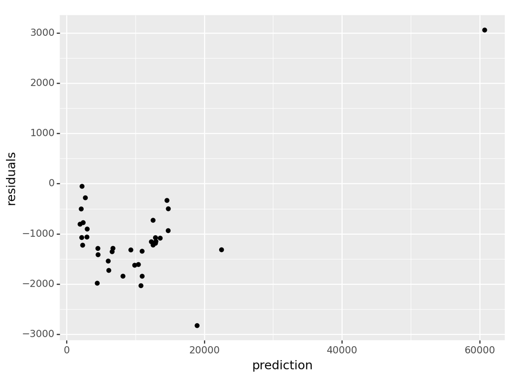

```
<Figure Size: (640 x 480)>
```

```python
(ggplot(plot2, aes(x = 'prediction', y = 'residuals'))
+ geom_point( color = 'black'))
```